# Project I: Performance Evaluation of Bandit Algorithms

> 盛宽 2021533152 shengkuan@shanghaitech.edu.cn

> 颜晨昕 2021533163 yanchx1@shanghaitech.edu.cn

### $\epsilon$-greedy Algorithm ($0 \leq \epsilon \leq 1$)

[figure not shown]

### UCB (Upper Confidence Bound) Algorithm

[figure not shown]

### TS (Thompson Sampling) Algorithm

[figure not shown]

### Problems

1. Now suppose we obtain the parameters of the Bernoulli distributions from an oracle, which are shown in the following table. Choose $N=5000$ and compute the theoretically maximized expectation of aggregate rewards over $N$ time slots. We call it the oracle value. Note that these parameters $\theta_{j}, j \in \{1,2,3\}$ and oracle values are unknown to all bandit algorithms.

| Arm $j$ | 1 | 2 | 3 |
| --- | --- | --- | --- |
| $\theta_j$ | 0.7 | 0.5 | 0.4 |

**Your anwser of problem 1 in Part I**

The theoretically maximized expectation of aggregate rewards over $N=5000$ time slots is: $$\max_{I(t),t=1,\ldots,N} \ \ \mathbb{E}\left[\sum_{t=1}^N r_{I(t)} \right] = N \cdot \theta_{I^*} = 5000 \cdot 0.7 = 3500.$$ Therefore, the oracle value is 3500.

1. Implement aforemented three classical bandit algorithms with following settings:
   - $N=5000$
   - $\epsilon$-greedy with $\epsilon \in \{0.1, 0.5, 0.9\}$.
   - UCB with $c \in \{1,5,10\}$.
   - TS with
     - $\left\{(\alpha_1,\beta_1)=(1,1),(\alpha_2,\beta_2)=(1,1),(\alpha_3,\beta_3)=(1,1)\right\}$
     - $\left\{(\alpha_1,\beta_1)=(601,401),(\alpha_2,\beta_2)=(401,601),(\alpha_3,\beta_3)=(2,3)\right\}$

**Your anwser of problem 2 in Part I**

```python
import matplotlib.pyplot as plt
import numpy as np
import random, math, copy

### Import more packages if you need
```

```python
### Implementation of epsilon-Greedy:
### n is the number of time slots, epsilon is the parameter of the algorithm
### return the total reward
def epsilon_greedy(n, epsilon):
    # initialize
    theta = np.array([0.5, 0.7, 0.4]) #the true distribution
    theta_hat = np.zeros(3)
    arm_count = np.zeros(3)
    rewards = np.zeros(n)

    for t in range(n):
        # choose an arm
        if np.random.random() < epsilon:
            # explore
            arm = np.random.choice(3)
        else:
            # exploit
            arm = np.argmax(theta_hat)

        # draw a reward from the chosen arm
        reward = np.random.binomial(1, theta[arm])

        # update the estimate of the chosen arm
        arm_count[arm] += 1
        theta_hat[arm] += (reward - theta_hat[arm]) / arm_count[arm]

        # record the reward
        rewards[t] = reward

    return np.sum(rewards)
```

```python
### Implementation of UCB Algorithm:
### n is the number of time slots, c is the parameter of the algorithm
### return the total reward
def UCB(n, c):
    theta = np.array([0.7, 0.5, 0.4]) #the true distribution
    arm_count = np.zeros(3)
    theta_hat = np.zeros(3)
    rewards = np.zeros(n)

    for t in range(3):
        #select the arm
        arm = t
        arm_count[arm] = 1
        reward = np.random.binomial(1, theta[arm])
        theta_hat[arm] = reward
        rewards[t] = reward

    for t in range(3, n):
        #select the arm
        theta_hat_tmp = theta_hat + c * np.array(
            [np.sqrt(2 * np.log(t+1) / arm_count[i]) for i in range(0,3)])
        arm = np.argmax(theta_hat_tmp)

        # draw a reward from the chosen arm
        reward = np.random.binomial(1, theta[arm])

        # update the estimate of the chosen arm
        arm_count[arm] += 1
        theta_hat[arm] += (reward - theta_hat[arm]) / arm_count[arm]

        # record the reward
        rewards[t] = reward

    return np.sum(rewards)
```

```python
### Implementation of TS Algorithm
### n is the number of time slots, a and b are the parameters of the algorithm
### return the total reward
def TS(n, a , b):
    alpha = np.array(a)
    beta = np.array(b)

    theta_hat = np.zeros(3)
    theta = np.array([0.7, 0.5, 0.4]) #the true distribution
    rewards = np.zeros(n)

    for t in range(n):
        #sample the model
        for j in range(3):
            theta_hat[j] = np.random.beta(alpha[j], beta[j])
        #select the arm
        arm = np.argmax(theta_hat)
        # draw a reward from the chosen arm
        reward = np.random.binomial(1, theta[arm])
        rewards[t] = reward
        alpha[arm] += reward
        beta[arm] += 1 - reward

    return np.sum(rewards)
```

1. Regard each of the above setting in problem 2 of Part I as an experiment (in total $8$ experiments). Run each experiment $200$ independent trials (change the random seed). Plot the final result (in terms of rewards and regrets) averaged over these $200$ trials.

**Your anwser of problem 3 in Part I**

```python
### Your code for problem 1.3. Feel free to insert more blocks or helper functions if you need.
#Now we try to implement the algorithems with the above parameters.
N = 5000
ep = [0.1, 0.5, 0.9]
c = [1, 5, 9]
ab = [[(1,1,1), (1,1,1)], [(601, 401, 2), (401, 601, 3)]]
```

```
The averaged result for epsilon =  0.1 is: rewards: 3397.855 regrets: 102.14499999999998
The averaged result for epsilon =  0.5 is: rewards: 3083.295 regrets: 416.7049999999999
The averaged result for epsilon =  0.9 is: rewards: 2751.955 regrets: 748.0450000000001
```

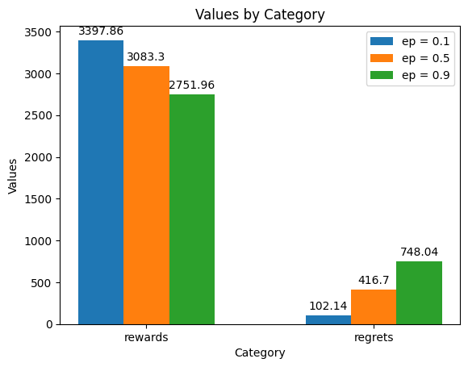

```python
results = []

for epsilon in ep:
    result = 0
    for i in range(200):
        np.random.seed(i)
        result += epsilon_greedy(N, epsilon)
    results.append((round(result/200,2), round(3500 - result/200,2)))
    print("The averaged result for epsilon = ", epsilon,"is: rewards:", result/200, "regrets:", 3500 - result/200)

# Create data
labels = ['rewards', 'regrets']
eps_result = [[results[i][0], results[i][1]] for i in range(len(ep)) ]

x = np.arange(len(labels))
width = 0.2

# Create bar chart
fig, ax = plt.subplots()
rects1 = ax.bar(x - width, eps_result[0], width, label='ep = 0.1')
rects2 = ax.bar(x, eps_result[1], width, label='ep = 0.5')
rects3 = ax.bar(x + width, eps_result[2], width, label='ep = 0.9')

# Add labels, title and axis ticks
ax.set_xlabel('Category')
ax.set_ylabel('Values')
ax.set_title('Values by Category')
ax.set_xticks(x)
ax.set_xticklabels(labels)
ax.legend()

# Display y values on bars
def autolabel(rects):
    for rect in rects:
        height = rect.get_height()
        ax.annotate('{}'.format(height),
                    xy=(rect.get_x() + rect.get_width() / 2, height),
                    xytext=(0, 3),  # 3 points vertical offset
                    textcoords="offset points",
                    ha='center', va='bottom')

autolabel(rects1)
autolabel(rects2)
autolabel(rects3)

plt.show()
```

```
The averaged result for UCB, c =  1 is: rewards: 3415.815 regrets: 84.18499999999995
The averaged result for UCB, c =  5 is: rewards: 2981.195 regrets: 518.8049999999998
The averaged result for UCB, c =  9 is: rewards: 2846.795 regrets: 653.2049999999999
```

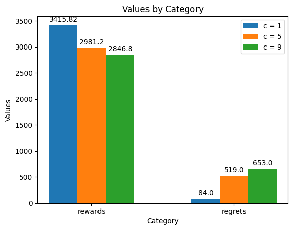

```python
results = []

for const in c:
    result = 0
    for i in range(200):
        np.random.seed(i)
        result += UCB(N, const)
    results.append((round(result/200,2), round(3500 - result/200)))
    print("The averaged result for UCB, c = ", const,"is: rewards:", result/200, "regrets:", 3500 - result/200)

# Create data
labels = ['rewards', 'regrets']
UCB_results = [[results[i][0], results[i][1]] for i in range(len(ep)) ]

x = np.arange(len(labels))
width = 0.2


# Create bar chart
fig, ax = plt.subplots()
rects1 = ax.bar(x - width, UCB_results[0], width, label='c = 1')
rects2 = ax.bar(x, UCB_results[1], width, label='c = 5')
rects3 = ax.bar(x + width, UCB_results[2], width, label='c = 9')

# Add labels, title and axis ticks
ax.set_xlabel('Category')
ax.set_ylabel('Values')
ax.set_title('Values by Category')
ax.set_xticks(x)
ax.set_xticklabels(labels)
ax.legend()

autolabel(rects1)
autolabel(rects2)
autolabel(rects3)
plt.show()
```

```
The averaged result for TS, a = (1, 1, 1), b = (1, 1, 1), is rewards: 3483.245, regrets: 16.75500000000011
The averaged result for TS, a = (601, 401, 2), b = (401, 601, 3), is rewards: 3493.96, regrets: 6.039999999999964
```

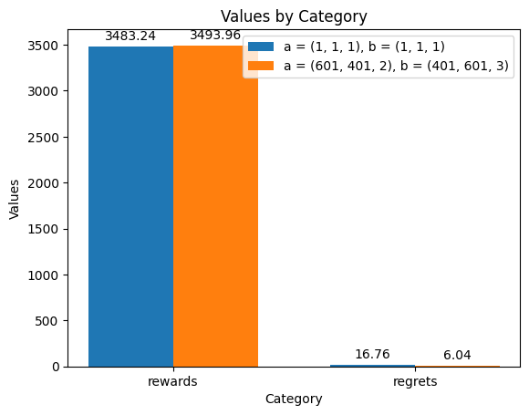

```python
N = 5000

results = []
for a, b in ab:
    result = 0
    for j in range(200):
        np.random.seed(j)
        result += TS(N, a, b)
    results.append((round(result/200,2), round(3500 - result/200,2)))
    print(f"The averaged result for TS, a = {a}, b = {b}, is rewards: {result/200}, regrets: {3500 - result/200}")

# Create data
labels = ['rewards', 'regrets']
TS_result = [[results[i][0], results[i][1]] for i in range(len(ab)) ]

x = np.arange(len(labels))
width = 0.35

# Create bar chart
fig, ax = plt.subplots()
rects1 = ax.bar(x - width/2, TS_result[0], width, label='a = (1, 1, 1), b = (1, 1, 1)')
rects2 = ax.bar(x + width/2, TS_result[1], width, label='a = (601, 401, 2), b = (401, 601, 3)')

# Add labels, title and axis ticks
ax.set_xlabel('Category')
ax.set_ylabel('Values')
ax.set_title('Values by Category')
ax.set_xticks(x)
ax.set_xticklabels(labels)
ax.legend()

autolabel(rects1)
autolabel(rects2)

plt.show()
```

1. Compute the gaps between the algorithm outputs (aggregated rewards over $N$ time slots) and the oracle value. Compare the numerical results of $\epsilon$-greedy, UCB, and TS.
   - Which one is the best?
   - Discuss the impacts of $\epsilon$, $c$, and $\alpha_{j}$, $\beta_{j}$, respectively.

**Your anwser of problem 4 in Part I**

```python
#some parameters
trials = range(100, 5000, 20)
ep = [0.1, 0.5, 0.9]
c = [1, 5, 9]
ab = [[(1,1,1), (1,1,1)], [(601, 401, 2), (401, 601, 3)]]
```

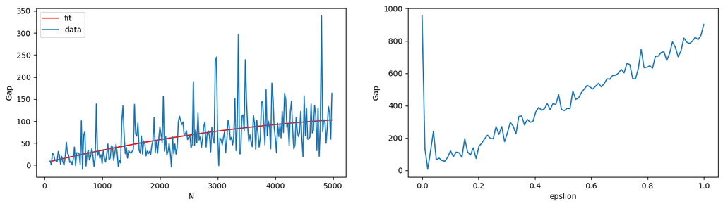

```python
eps_gap = np.array([(0.7*n - epsilon_greedy(n, 0.1)) for n in trials])
fit = np.polyfit(trials, eps_gap, deg=2)
fit_func = np.poly1d(fit)

plt.figure(figsize=(16, 4))

plt.subplot(1, 2, 1)
plt.plot(trials, fit_func(trials), c='r', label='fit')
plt.plot(trials, eps_gap, label='data')
plt.xlabel("N")
plt.ylabel("Gap")
plt.legend()
eps_gap = np.array([3500 - epsilon_greedy(5000, e) for e in np.linspace(0, 1, 100)])

plt.subplot(1, 2, 2)
plt.plot(np.linspace(0, 1, 100), eps_gap)
plt.xlabel("epslion")
plt.ylabel("Gap")

plt.show()
```

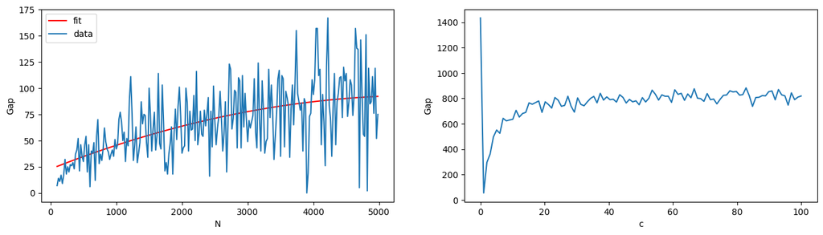

```python
UCB_gap = [(0.7*n - UCB(n, 1)) for n in trials]
fit = np.polyfit(trials, UCB_gap, deg=2)
fit_func = np.poly1d(fit)

plt.figure(figsize=(16, 4))

plt.subplot(1, 2, 1)
plt.plot(trials, fit_func(trials), c='r',label='fit')
plt.plot(trials, UCB_gap, label='data')
plt.xlabel("N")
plt.ylabel("Gap")
plt.legend()
UCB_gap = np.array([3500 - UCB(5000, c) for c in np.linspace(0, 100, 100)])

plt.subplot(1, 2, 2)
plt.plot(np.linspace(0, 100, 100), UCB_gap)
plt.xlabel("c")
plt.ylabel("Gap")
plt.show()
```

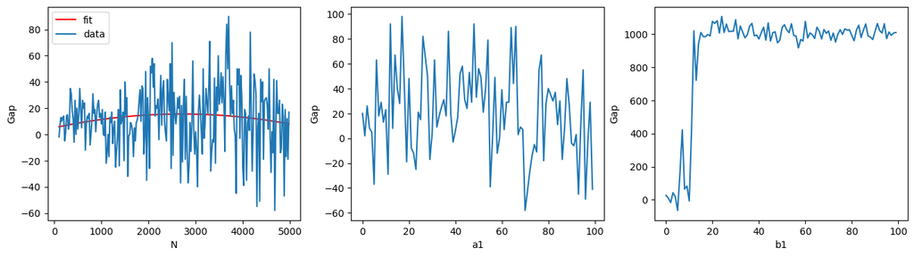

```python
from random import random as r

TS_gap = [(0.7*n - TS(n, ab[0][0], ab[0][1])) for n in trials]
fit = np.polyfit(trials, TS_gap, deg=2)
fit_func = np.poly1d(fit)

plt.figure(figsize=(16, 4))

plt.subplot(1, 3, 1)
plt.plot(trials, fit_func(trials), c='r',label='fit')
plt.plot(trials, TS_gap, label = 'data')
plt.xlabel("N")
plt.ylabel("Gap")
plt.legend()
TS_gap = np.array([3500 - TS(5000, (i+1, 1, 1),
                             (1, 1, 1))
                   for i in range(100)])

plt.subplot(1, 3, 2)
plt.plot(range(100), TS_gap)
plt.xlabel("a1")
plt.ylabel("Gap")
TS_gap = np.array([3500 - TS(5000, (1, 1, 1),
                             (i+1, 1, 1))
                   for i in range(100)])

plt.subplot(1, 3, 3)
plt.plot(range(100), TS_gap)
plt.xlabel("b1")
plt.ylabel("Gap")
plt.show()
```

Notice! there is a tricky problem that `np.random.binomial(np.array([a1, a2, a3]))` will default choose the first value when `a1=a2=a3=0.`, so if the first arm is the best choice, we will not find the ascending process in epislon-greedy

1. Give your understanding of the exploration-exploitation trade-off in bandit algorithms.

**Your anwser of problem 5 in Part I**

- Greedy algorithm is a direct thinking to use exploration-exploitation, we have probability $\epsilon$ to explore which is represented as randomly selecting an arm, and the probability $1-\epsilon$ to exploitation which means we choose $\underset{j \in\{1,2,3\}}{\arg \max }\ \widehat{\theta}(j)$
- UCB algorithm has a exploration-exploitation trade-off when choose arms. Firstly, we will choose the third arms one by one. Next, we choose the best estimation. Each Arm has a confidence interval for the mean value of the return, which becomes narrower as the number of trials increases (gradually determining whether the return is generous or poor). Before each selection, the mean value and confidence interval of each arm are re-estimated based on the results of the previous trials. The arm with the highest confidence interval is selected.
- TS algorithm is essentially different from the previous two algorithms. It does not use a fixed parameter to adjust the probability of exploration, but contains the trade-off between exploration and exploitation in the comparison of the expectation of each arm’s income. The prior distribution we present affects the final payoff in two ways. On the one hand, it is to predict the income of each arm. The more accurate this prediction is, the lower the trial and error cost in the experiment, and the optimal arm can be selected more accurately from the beginning. On the other hand, there is the ”number of experiments” of the prior distribution, that is, the size of $\alpha$ and $\beta$. If these two values are relatively large, it means that we have done a large number of experiments in advance. If the prediction is accurate, the loss caused by the contingency of the initial several experiments can be effectively avoided.
1. We implicitly assume the reward distribution of these three arms are independent. How about the dependent case? Can you design an algorithm to exploit such information to obtain a better result?

**Your anwser of problem 6 in Part I**

For the dependent case, as we consider that if the distribution of three arms are independent, then the algorithm will most likely focus on the arm whose prior distribution has a higher expectation thus will always focus on it even if it fails a lot of times. So we let each trial on one arm will also affect other arms.

```python
def TS_dependent(n, a , b):
    alpha = np.array(a)
    beta = np.array(b)
    theta = np.array([0.7, 0.5, 0.4])
    theta_hat = np.zeros(3)
    rewards = 0

    for t in range(n):
        #sample the model
        for j in range(3):
            theta_hat[j] =  np.random.beta(alpha[j], beta[j])
        #select the arm
        arm = np.argmax(theta_hat)
        # draw a reward from the chosen arm
        reward = np.random.binomial(1,theta[arm])
        rewards += reward
        alpha[arm] += reward
        beta[arm] += 1 - reward
        # Success or not on one arm will also affect another arm
        for j in range(3):
            if j != arm:
                beta[j] += reward
                alpha[j] += 1 - reward
    return rewards
result = 0
for i in range(200):
    np.random.seed(i)
    result += TS_dependent(5000,[1,1,1],[1,1,1])
print(f"The averaged result for TS_dependent, a = (1,1,1), b = (1,1,1), is rewards: {result/200}, bigger than dependent case 3483.24")
result = 0
for i in range(200):
    np.random.seed(i)
    result += TS_dependent(5000,[601,401,2],[401,601,3])
print(f"The averaged result for TS_dependent, a = (601,401,2), b = (401,601,3), is rewards: {result/200}, bigger than dependent case 3493.96")
```

```
The averaged result for TS_dependent, a = (1,1,1), b = (1,1,1), is rewards: 3493.97, bigger than dependent case 3483.24
The averaged result for TS_dependent, a = (601,401,2), b = (401,601,3), is rewards: 3502.07, bigger than dependent case 3493.96
```

## Part II: Bayesian Bandit Algorithms

There are two arms which may be pulled repeatedly in any order. Each pull may result in either a success or a failure. The sequence of successes and failures which results from pulling arm $i$ ($i \in \{1, 2\}$) forms a Bernoulli process with unknown success probability $\theta_{i}$. A success at the $t^{th}$ pull yields a reward $\gamma^{t-1}$ ($0 < \gamma <1$), while an unsuccessful pull yields a zero reward. At time zero, each $\theta_{i}$ has a Beta prior distribution with two parameters $\alpha_{i}, \beta_{i}$ and these distributions are independent for different arms. These prior distributions are updated to posterior distributions as arms are pulled. Since the class of Beta distributions is closed under Bernoulli sampling, posterior distributions are all Beta distributions. How should the arm to pull next in each time slot be chosen to maximize the total expected reward from an infinite sequence of pulls?

1. One intuitive policy suggests that in each time slot we should pull the arm for which the current expected value of $\theta_{i}$ is the largest. This policy behaves very good in most cases. Please design simulations to check the behavior of this policy.

**Your anwser of problem 1 in Part II**

```
For a1 = 1, b1 = 1, a2 = 1, b2 = 1, gama = 0.9, N = 5000, the reward is: 6.043103200467275
For a1 = 5, b1 = 4, a2 = 6, b2 = 9, gama = 0.9, N = 5000, the reward is: 5.694150320842012
```

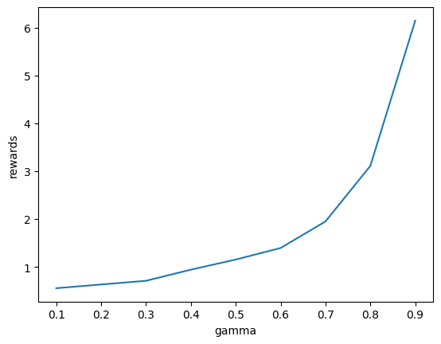

```python
N = 5000
# Your code for problem 2.1. Feel free to insert more blocks or helper functions if you need.


def Bayesian_alg1(a1, b1, a2, b2, n, gamma):
    reward = 0
    success = 0
    for i in range(n):
        expect1 = a1/(a1+b1)
        expect2 = a2/(a2+b2)
        if expect1 > expect2:
            proba = np.random.beta(a1, b1)
            if (np.random.binomial(1, proba)):
                a1 += 1
                reward += gamma**i
                success += 1
            else:
                b1 += 1
        else:
            proba = np.random.beta(a2, b2)
            if (np.random.binomial(1, proba)):
                a2 += 1
                reward += gamma**i
                success += 1
            else:
                b2 += 1

    return reward


params = [(1, 1, 1, 1, 0.9), (5, 4, 6, 9, 0.9)]
for a1, b1, a2, b2, gamma in params:
    result = 0
    for i in range(200):
        np.random.seed(i)
        result += Bayesian_alg1(a1, b1, a2, b2, N, gamma)
#         print(result)
    print(
        f"For a1 = {a1}, b1 = {b1}, a2 = {a2}, b2 = {b2}, gama = {gamma}, N = {N}, the reward is: {result / 200}")
result = []
gamma = [0.1, 0.2, 0.3, 0.4, 0.5, 0.6, 0.7, 0.8, 0.9]
for each in gamma:
    tt = 0
    for i in range(200):
        tt += Bayesian_alg1(1, 1, 1, 1, N, each)
    result.append(tt/200)
plt.plot(gamma,result)
plt.xlabel("gamma")
plt.ylabel("rewards")
```

1. However, such intuitive policy is unfortunately not optimal. Please provide an example to show why such policy is not optimal.

For the intuitive policy designed above, we can find out that the prior distributions of the two arms are very important, but if the expectation of the two prior distributions varied a lot, then it's possible that the intuitive policy will only focus on an single arm thus ignoring anther arm. For instance, Beta(7,1) and Beta(1,1), the second will be very likely to be ignored.

**Your anwser of problem 2 in Part II**

1. For the expected total reward under an optimal policy, show that the following recurrence equation holds:

\begin{equation*} \begin{aligned} R_{1}(\alpha_{1},\beta_{1}) = & \frac{\alpha_{1}}{\alpha_{1}+\beta_{1}} [1+\gamma R(\alpha_{1} + 1, \beta_{1}, \alpha_{2}, \beta_{2})] \\ & + \frac{\beta_{1}}{\alpha_{1} + \beta_{1}} [\gamma R(\alpha_{1}, \beta_{1} + 1, \alpha_{2}, \beta_{2})]; \\ R_{2}(\alpha_{2}, \beta_{2}) = & \frac{\alpha_{2}}{\alpha_{2} + \beta_{2}} [1 + \gamma R(\alpha_{1}, \beta_{1}, \alpha_{2} + 1, \beta_{2})] \\ & + \frac{\beta_{2}}{\alpha_{2} + \beta_{2}} [\gamma R(\alpha_{1}, \beta_{1}, \alpha_{2}, \beta_{2} + 1)]; \\ R(\alpha_{1}, \beta_{1}, \alpha_{2}, \beta_{2}) = & \max \left\{ R_{1}(\alpha_{1}, \beta_{1}), R_{2}(\alpha_{2}, \beta_{2}) \right\}. \end{aligned} \end{equation*}

**Your anwser of problem 3 in Part II**

Here we take $R_1(\alpha_1,\beta_1)$ into two parts: the first time the rewards we get if we select the first arm with the rewards afterwards.

First if the first trial is a success, then afterwards, we need to add rewards $\gamma^{(t-1)}=1$, and we turn $\alpha_1 $ to be $\alpha_1+1$, and also we need to multiply the rewards afterwards by $\gamma$.

Next if we failed on the first trial, then there is no need to add rewards, so that is: $$ \begin{align*} R_{1}(\alpha_{1},\beta_{1}) = & \frac{\alpha_{1}}{\alpha_{1}+\beta_{1}} [1+\gamma R(\alpha_{1} + 1, \beta_{1}, \alpha_{2}, \beta_{2})] \\ & + \frac{\beta_{1}}{\alpha_{1} + \beta_{1}} [\gamma R(\alpha_{1}, \beta_{1} + 1, \alpha_{2}, \beta_{2})]; \end{align*} $$

and it's the same with $R_2$, due to our algorithm, the first trial should be the arm with $\theta$ expectation bigger, so we know that is:

$$ \begin{align*} R(\alpha_{1}, \beta_{1}, \alpha_{2}, \beta_{2}) = & \max \left\{ R_{1}(\alpha_{1}, \beta_{1}), R_{2}(\alpha_{2}, \beta_{2}) \right\}. \end{align*} $$

1. For the above equations, how to solve it exactly or approximately?

**Your anwser of problem 4 in Part II**

```python
# Your code for problem 2.4 if needed.
import time
from scipy import optimize as op
from matplotlib import pyplot as plt

def recursive_naive(a1, b1, a2, b2, n, gamma):
    if n == 1:
        return max(a1/(a1+b1), a2/(a2+b2))

    else:
        return max((a1/(a1+b1))*(1 + gamma * recursive_naive(a1+1, b1, a2, b2, n-1, gamma))
                   + (b1/(a1+b1))*(gamma * recursive_naive(a1, b1+1, a2, b2, n-1, gamma)),
                   (a2/(a2+b2))*(1 + gamma * recursive_naive(a1, b1, a2+1, b2, n-1, gamma))
                   + (b2/(a2+b2))*(gamma * recursive_naive(a1, b1, a2, b2+1, n-1, gamma))
                   )

print(f"the reward is {recursive_naive(1,1,1,1,10,0.9)} with N = 10, gamma = 0.9")
```

```
the reward is 3.8570958886978577 with N = 10, gamma = 0.9
```

Furthermore, we find there is too much recursion in this implement, thus making this function running extremly slow, and even raise error with large $N$ (e.g. when $N=100$) for exceed the limitation of recursion branch ,

We can easily found the same value $R(\alpha_1, \beta_1, \alpha_2, \beta_2)$ was called many times, thus we can accelerate it by storing the $R$ values in a cache with key $(\alpha_1, \beta_1, \alpha_2, \beta_2)$, and load it directly if it has been calculated

```python
# Your code for problem 2.4 if needed.
# Your code for problem 2.4 if needed.
from scipy import optimize as op
from matplotlib import pyplot as plt


gamma = [0.1, 0.2, 0.3, 0.4, 0.5, 0.6, 0.7, 0.8, 0.9]
# Here we just set a1, b1, a2, b2 to be 1 for convenience
result = []
N = 10


cache = {(0,0,0,0):0}

def recursive(a1, b1, a2, b2, n, gamma):
    if n == 1:
        return max(a1/(a1+b1), a2/(a2+b2))
    else:
        if ((a1+1, b1, a2, b2) in cache):
            t1 = cache[(a1+1, b1, a2, b2)]
        else:
            t1 = recursive(a1+1, b1, a2, b2, n-1, gamma)
            cache[(a1+1, b1, a2, b2)] = t1

        if ((a1, b1+1, a2, b2) in cache):
            t2 = cache[(a1, b1+1, a2, b2)]
        else:
            t2 = recursive(a1, b1+1, a2, b2, n-1, gamma)
            cache[(a1, b1+1, a2, b2)] = t2

        if ((a1, b1, a2+1, b2) in cache):
            t3 = cache[(a1, b1, a2+1, b2)]
        else:
            t3 = recursive(a1, b1, a2+1, b2, n-1, gamma)
            cache[(a1, b1, a2+1, b2)] = t3

        if ((a1, b1, a2, b2+1) in cache):
            t4 = cache[(a1, b1, a2, b2+1)]
        else:
            t4 = recursive(a1, b1, a2, b2+1, n-1, gamma)
            cache[(a1, b1, a2, b2+1)] = t4

        r1 = a1/(a1 + b1)*(1+gamma*t1) + b1/(a1 + b1)*(gamma*t2)
        r2 = a2/(a2 + b2)*(1+gamma*t3) + b2/(a2 + b2)*(gamma*t4)

        return max(r1, r2)
        # ss = t1 + t2
        # sss = t3 + t4
        # return max(ss, sss)
print(f"the reward is {recursive(1,1,1,1,N,0.9)} with N = 100, gamma = 0.9", end="\n\n")


t1 = time.time()
recursive_naive(1,1,1,1,13,0.9)
print(f"Naive function cost {time.time() - t1:.3}s with N = 13")

cache = {(0,0,0,0):0}
t1 = time.time()
recursive(1,1,1,1,13,0.9)
print(f"Function with cache cost {time.time() - t1:.3}s with N = 13")
```

[output not shown]

We can see that there is a very large improvement with our optimization

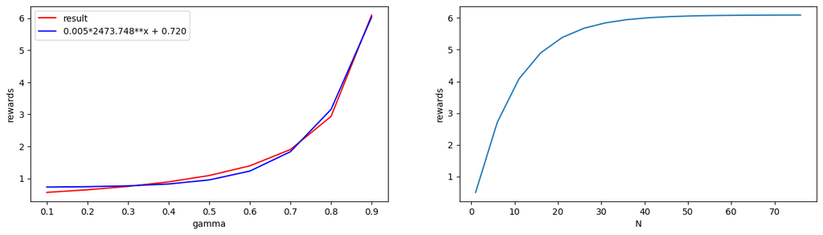

```python
gammas = [0.1, 0.2, 0.3, 0.4, 0.5, 0.6, 0.7, 0.8, 0.9]
result = []

plt.figure(figsize=(16, 4))

for each in gammas:
    cache = {(0, 0, 0, 0, 0): 0}
    result.append(recursive(1, 1, 1, 1, 100, each))


def func(x, a, b, c):
    return a*(b**x)+c


a, b = op.curve_fit(func, gammas, result)
fit = [func(i, a[0], a[1], a[2])for i in gammas]
plt.subplot(1, 2, 1)
plt.plot(gammas, result, 'r', label = "result")
plt.plot(gammas, fit, 'b', label = f"{a[0]:.3f}*{a[1]:.3f}**x + {a[2]:.3f}")
plt.xlabel("gamma")
plt.ylabel("rewards")
plt.legend()

nt = range(1, 80, 5)
ans = []

for each in nt:
    cache = {(0, 0, 0, 0, 0): 0}
    ans.append(recursive(1, 1, 1, 1, each, 0.9))
plt.subplot(1, 2, 2)
plt.plot(nt, ans)
plt.xlabel("N")
plt.ylabel("rewards")
plt.show()
```

By observing the image, we found that the obtained data can be well fitted with the exponential function $0.005\times 2473.748^x + 0.720$. Also we can find out that when N is over 100, the rewards will increase only a very small amount that can be ignored. Therefore, we can solve it exactly by our accelerated recurrsion function, or we can use this exponential function to get an approximate with $O(1)$ time cost

1. Find the optimal policy.

**Your anwser of problem 5 in Part II**

In problem 4, we have accelerated the recurrsion process by store the same value. It give a way to calculate optimal value when `n` is small. Now, we combime the intuitive policy with the recurrsion process to get the optimal policy

We can use the recusion function to compute the expected total reward for a given set of prior parameters, and then optimize over the arms by updating the priors as we pull them using `Bayesian_alg1`.

```python
def Bayesian_alg1(a1, b1, a2, b2, n, gamma):
    reward = 0
    success = 0
    for i in range(n):
        expect1 = a1/(a1+b1)
        expect2 = a2/(a2+b2)
        if expect1 > expect2:
            proba = np.random.beta(a1, b1)
            if (np.random.binomial(1, proba)):
                a1 += 1
                reward += gamma**i
                success += 1
            else:
                b1 += 1
        else:
            proba = np.random.beta(a2, b2)
            if (np.random.binomial(1, proba)):
                a2 += 1
                reward += gamma**i
                success += 1
            else:
                b2 += 1
    return reward

storage = [1,1,1,1]
cache = {(0,0,0,0):0}
def recursive(a1, b1, a2, b2, n, gamma):
    if n == 1:
        return max(a1/(a1+b1), a2/(a2+b2))
    else:
        if ((a1+1, b1, a2, b2) in cache):
            t1 = cache[(a1+1, b1, a2, b2)]
        else:
            t1 = recursive(a1+1, b1, a2, b2, n-1, gamma)
            cache[(a1+1, b1, a2, b2)] = t1

        if ((a1, b1+1, a2, b2) in cache):
            t2 = cache[(a1, b1+1, a2, b2)]
        else:
            t2 = recursive(a1, b1+1, a2, b2, n-1, gamma)
            cache[(a1, b1+1, a2, b2)] = t2

        if ((a1, b1, a2+1, b2) in cache):
            t3 = cache[(a1, b1, a2+1, b2)]
        else:
            t3 = recursive(a1, b1, a2+1, b2, n-1, gamma)
            cache[(a1, b1, a2+1, b2)] = t3

        if ((a1, b1, a2, b2+1) in cache):
            t4 = cache[(a1, b1, a2, b2+1)]
        else:
            t4 = recursive(a1, b1, a2, b2+1, n-1, gamma)
            cache[(a1, b1, a2, b2+1)] = t4

        r1 = a1/(a1 + b1)*(1+gamma*t1) + b1/(a1 + b1)*(gamma*t2)
        r2 = a2/(a2 + b2)*(1+gamma*t3) + b2/(a2 + b2)*(gamma*t4)

        if (r1 >= r2):
            proba = np.random.beta(a1, b1)
            if (np.random.binomial(1, proba)):
                storage[0] = max(a1 + 1, storage[0])
            else:
                storage[1] = max(b1 + 1, storage[1])
        else:
            proba = np.random.beta(a1, b1)
            if (np.random.binomial(1, proba)):
                storage[2] = max(a2 + 1, storage[2])
            else:
                storage[3] = max(b2 + 1, storage[3])

        return max(r1, r2)


def find_optimal_policy(a1, b1, a2, b2, n, gamma):
    if n < min(n/2, 50):
        return recursive(a1, b1, a2, b2, n, gamma)
    else:
        reward = recursive(a1, b1, a2, b2, 10, gamma)
        return reward + Bayesian_alg1(storage[0], storage[1], storage[2], storage[3], n, gamma**3)

find_optimal_policy(1, 1, 1, 1, 100, 0.9)
```

```
6.022725439805908
```